# historyofsciencefiction

"Deadline" was a short work of science fiction published to *Astounding Stories* in the year 1944. Its premise surrounded the separation of radioactive isotopes, namely uranium-235, to create a nuclear fission device. The story was published at around the same time the Manhattan Project was underway, and prompted an investigation by the FBI into its author's— Cleve Cartmill's— knowledge of the weapon.[1](https://web.archive.org/web/20130618175748/http://www.asimovs.com/_issue_0310/ref.shtml) Allegedly, Cartmill was already aware that the United States government was constructing an atomic weapon. He apparently cited that subscribers to the *Astounding Stories* magazine, many of whom were physicists and engineers, had all suddenly changed their addresses to Los Alamos, New Mexico.

What is known for certain, however, is that the editor of *Astounding Stories* at the time, John Campbell, is recorded to have corresponded with Cartmill on the subject of a so-called "super-bomb.” He mentioned the concept of using atomic weaponry in warfare, directing him to scientific articles describing a process whereby fissionable uranium-235 can be generated. [2]

[2]: https://www.gwern.net/docs/1984-berger.pdf Refer to page 8 of the PDF, corresponding to p.132

The FBI’s investigation also led them to H. G. Wells and Robert A. Heinlein, both are well known science fiction authors today. It is worth noting that H. G. Wells, though he is better known for novels like *War of the Worlds* and *The Time Machine,* also wrote a novel depicting the use of nuclear weaponry— though of a slightly different form— titled *The World Set Free.*

This anecdote begs the question: **what can the trends of science fiction reveal about history?** The history of science fiction in itself is already well-tread ground, but even a cursory knowledge of the genre hints toward a deeper relationship between itself and developments in conventional science. One of the agreed-upon founders of science fiction, Mary Shelley, was openly inspired by research into “animal electricity” to create the premise of *Frankenstein.* In a more topical vein, there is a clear trend in the depiction of nuclear radiation following Hiroshima and Nagasaki, one that notably differs between the United States and Japan.

The common approach to the history of science fiction is often focused upon a few authors and their contributions to the genre. There are the well-known and agreed-upon founders, Mary Shelley and some of the "fathers of science fiction," H. G. Wells, Jules Vernes, Isaac Asimov, et cetera. There is alway the occasional detour, mentioning the likes of H. P. Lovecraft or Frank Herbert, who both revolutionised the genre in their own ways. While this approach is good, it inevitably constrains itself to popular or singular works, which might not be totally representative of the entire genre at that time. Additionally, while innovative writers have had extreme influence on the genre, such an approach may miss this influence upon lesser-known works of science fiction.

A possible solution is to take a more broad approach, using data-driven techniques to analyse science fiction as a whole. This approach is obviously missing the keen focus mentioned beforehand, but for what it lacks in popular authorship, it makes up in representation and zeitgeist. More eminently, however, the upcoming techniques and analyses may be used at a much larger scale to analyse *any* body of work, not simply science fiction. What follows is a methodological exploration. The intention is to investigate the relationship between conventional science and science fiction, much in the way the introductory anecdote suggests.

It would help to first define what it means for a work to be “science fiction” in the first place. Generally, a narrative is called “science fiction” either when its premise cannot exist without the inclusion some scientific concept or when its plot centres around a certain technology. Strangely enough, by this definition, certain works cannot strictly be called “science fiction,” most notably *Star Wars,* in which every idea can be traded for a corresponding idea of traditional fantasy. For the purpose of upcoming analyses, however, “science fiction” may as well be defined narrowly, as “anything which has been published to a pulp magazine popular after 1920s." The general definition is only present to create a connection between science fiction narrative and the history of conventional science.

And to represent conventional science, data will be pulled from *Nature,* one of the largest and broadest scientific journals in history. *Nature* publishes articles covering a wide variety of subjects, including, but not limited to: biology, physics, chemistry, psychology, metaanalyses, commentary, et cetera. As implied by the *Amazing Stories* dataset, the *Nature* dataset will only cover English language articles.

It is worth mentioning the potential for loss in the datasets, as the accrual of both met certain drawbacks and limitations. The chosen reference index of *Amazing Stories* does not contain permanent archives for every single issue, thereby incurring some loss. The chosen method for gathering *Nature* articles is unable to guarantee there is an abstract for all entries; additionally, a combination of the sheer abundance of data, user impatience, and poor internet connection forced the dataset to be culled by way of skipping entries. Each instance of loss will be elaborated upon when relevant.

Docstrings, which are formed by surrounding plaintext in triple quotations (`"""`) are to take the place of markdown cells for all upcoming Python cells. The user is not strictly required to run any scripts except for S4 and S7.

When allowed to execute until the end of the available dataset— though not recommended— the Python cell below has a runtime of eight minutes and forty-seven seconds, and it yields 183 plaintext files into the user's default directory. These files will act as the dataset for the holistic analysis of science fiction. A folder containing all 183 documents will be provided alongside this Python notebook.

As there were many pulp magazines that specialised in science fiction, the dataset has been limited to the most easily accessible one on the internet: Amazing Stories. The script below is designed to scrape the internet for as many full text issues of the Amazing Stories periodical as possible, a set which just so happens to fall between the 1920s and the 1950s. There will not be an explanation for every single line; the lines deemed the most important will take priority.

The source for this analysis is the Online Books Page, a reference index containing links to permanent physical or digital archives for works of literature. In particular, the script is designed to scrape the page containing every available archive of Amazing Stories, all thankfully digital, and pull plaintext files into the user's directory.

The reference index contains links to three different online archives, those being HathiTrust, the Gutenberg Project, and the Internet Archive. A majority of the indeces come from the Internet Archive, so to save time, the lines above filter for only the links that go to archive.org, the Internet Archive's web domain.

```python
"""
SCRIPT #1
"""
## necessary imports
import requests
from bs4 import BeautifulSoup

site = requests.get("https://onlinebooks.library.upenn.edu/webbin/serial?id=amazingstories").text
soupsite = BeautifulSoup(site, "lxml")

references = soupsite.find("ul") # yields the 'unordered list' HTML element containing each reference link
references_links = references.find_all("a") # yields a list of HTML elements

archive_links = [i.get("href") for i in references_links if "archive.org" in i.get("href")] ## yields a list of direct links to archive.org archives
archive_titles = [i.text for i in references_links if "archive.org" in i.get("href")] ## yields volume and issue number

print(archive_titles)

good_links = [] ## empty list which by the end of the following loop should contain every necessary link
for link in archive_links:
    try:
        archive = requests.get(link).text
        souparchive = BeautifulSoup(archive, "lxml")

        sidebar_div = souparchive.find("div", class_="col-sm-4 thats-right item-details-archive-info")
        a_tags = sidebar_div.find_all("a")

        text_links = [i.get("href") for i in a_tags if "FULL TEXT" in i.text]

        good_links = good_links + text_links

        print(text_links)
    except:
        pass

for link in good_links:
    plaintext = requests.get(f"https://archive.org{link}").text ## link to a web archive which contains the plaintext inside a unique HTML tag
    soupplaintext = BeautifulSoup(plaintext, "lxml")

    best = soupplaintext.find("pre").text ## yields a string

    with open(f"{archive_titles[good_links.index(link)]}.txt", "w") as f:
        f.write(best)
```

By the variable names, it should be clear what is occurring inside this loop: for each iteration, the code will enter an archive.org link and locate the `<div>` element that represents a sidebar in the actual webpage. Within the sidebar, there is another link, labelled "FULL TEXT", that goes to the desired plaintext file, stored inside an HTML webpage withing a `<pre>` tag.

One hundred eighty-three text files is a lot of data, and one can be forgiven for refusing to read through it all manually. Python has an extremely simple solution. Below is a sample script originally designed to analyse the plaintext files scraped in the previous cell. This script yields an undated CSV file containing frequency data for a long list of terms. It is not recommended to run this script solely because it is not especially useful for the present analyses, though it does demonstrate a concept which will be eminent going forward. Said concept will be touched upon within an docstring when relevant.

```python
"""
SCRIPT #2
"""
import nltk ## natural language toolkit
import os
import csv

shortlist = [
    "alien","aliens","mars","quantum","radiation","venus","civilization","laser","lazer","light","horror","terror","space","war","conquest","colonize","invasion","body","snatcher","hidden","hiding","among","planet","extraterrestrial","terrestrial","plasma","cosmos","speed","universe","multiverse","hole","antimatter","anti","matter","orbit","orbital","blackhole","wormhole","hologram","holograph","holographic","computer","robot","nanotechnology","nanotech","nanoparticles","nanobots","nano","bots","droids","droid","android","androids","singularity","robots","event","horizon","black","spaghettification","raygun","gun","ray","rays","guns","spaceship","spaceships","galactic","ship","ships","empire","empires","quazar","quazars","beam","beams","warp","warps","drive","drives","teleport","teleportation","teleporter","teleporters","hyperdrive","tractor","interplanetary","planets","void","abyss","abyssal","neutron","neutrons","neuron","neurons","pizza","electron","electrons","proton","protons","star","stars","nuclear","atom","atoms","atomic","bomb","bombs","cryogenic","cryogenics"
]

print(f"{len(shortlist)} entries in 'shortlist'")

## directory-related things
current_directory = os.getcwd()
current_files = os.listdir(current_directory)
text_files = [i for i in current_files if i.endswith(".txt")]

## establishing the csv file
year_csv = open("year.csv", "w", newline="", encoding="utf-8")

csv_writer = csv.writer(year_csv)
csv_writer.writerow(["Year"]+shortlist)

## the dictionary is constructed using dict comprehension
statistics = {k:v for (k,v) in zip(shortlist,[0 for i in range(len(shortlist))])}
print(statistics)

for file in text_files:
    print(f"\n{file}")

    book = open(file, "r")
    book = book.read()
    book = book.lower()

    token_book = nltk.word_tokenize(book)
    rep_book = [i for i in token_book if i in shortlist] ## EXAMPLE

    for i in rep_book:
        statistics[i] += 1

#
print(f"{len(statistics.keys())} entries in 'statistics'")

csv_writer.writerow(["year"]+list(statistics.values()))

print(f"\n{statistics}")
#
```

The line labelled "`## EXAMPLE`" is an important factor in both hastening the analysis of the data and cleaning the data itself. The variable is formed using a unique tool of Python, called "list comprehension," which is a single line script that runs within the variable itself. Each term of the self-contained function has a particular use.

The first instance of 'i' in the function defines the data which will be saved to the list. The subsequent loop, 'for i in token_book if in shortlist' constrains or filters the list to a particular set of words. In this case, it is the 'shortlist' variable defined at the beginning of the script. This method of cleaning data appears extremely destructive, since every word in the dataset is lost except those that match the 'shortlist' variable. This is not truly the case, mercifully, since 'rep_book' is generated using a read-only process, which does not affect the original text file whatsoever.

Note the empty comment syntax surrounding the last few lines. Were everything between the two octothorps to be indented to line up with the for-loop, the csv_writer line above would run once for every document, and after runtime yield a complete CSV with data for all 183 documents.

Said CSV has hopefully been included with this notebook file under the name 'amazingstories.csv'.

In its current state, the script above is of little use. However, the technique of removing every unnecessary word will be eminent for upcoming analyses and data visualisations. The technique is especially effective in the case of the plaintext files generated in Script #1. If the user were to have opened any of the files extracted by S1, they would find that each contains a few lines of garbled text at the beginning. By first tokenising and then cleaning the files in a read-only manner, S2 demonstrates an efficient method for analysing only the frequency of highly relevant words. Articles, demonstratives, pronouns, and prepositions— which would normally be cleaned out as "stopwords"— are all automatically excluded during list comprehension. In this way, it is nearly possible to select any word and learn its frequency through the years of *Amazing Stories.* To get there, however, the script still needs work.

Two problems are immediately apparent. The first is obvious: there are no dates recorded. The second is slightly more abstract. Consider the following example to illustrate the problem:

The user wants to analyse the frequency of the word "dog" in a pair of files individually. They input the word and execute the script, and they are met with two values: File #1 contains 10 instances of the word, whereas File #2 contains 100. The user is left to conclude that "dog" has more significance in file two than File #1. Their conclusion, however, is not guaranteed to be accurate; F1 may contain exactly 10 words, inducing a 100% significance on the word "dog," likewise F2 may contain 100,000 words, inducing only a 0.1% significance. Correcting this discrepancy involves *normalising* the data, that is: dividing word frequency by the total number of words in the parent document. This process shrinks every value to the same relative size, preserving their relationships to one another in a manner that ensures direct comparability.

```python
"""
SCRIPT #3

This script is a modification of S2, and exists purely to demonstrate the above suggestions.
"""
import nltk
import os


shortlist = [
    "alien","aliens","mars","quantum","radiation","venus","civilization","laser","lazer","light","horror","terror","space","war","conquest","colonize","invasion","body","snatcher","hidden","hiding","among","planet","extraterrestrial","terrestrial","plasma","cosmos","speed","universe","multiverse","hole","antimatter","anti","matter","orbit","orbital","blackhole","wormhole","hologram","holograph","holographic","computer","robot","nanotechnology","nanotech","nanoparticles","nanobots","nano","bots","droids","droid","android","androids","singularity","robots","event","horizon","black","spaghettification","raygun","gun","ray","rays","guns","spaceship","spaceships","galactic","ship","ships","empire","empires","quazar","quazars","beam","beams","warp","warps","drive","drives","teleport","teleportation","teleporter","teleporters","hyperdrive","tractor","interplanetary","planets","void","abyss","abyssal","neutron","neutrons","neuron","neurons","pizza","electron","electrons","proton","protons","star","stars","nuclear","atom","atoms","atomic","bomb","bombs","cryogenic","cryogenics"
]

## directory-related things
current_directory = os.getcwd()
current_files = os.listdir(current_directory)
text_files = [i for i in current_files if i.endswith(".txt")]

for file in text_files:
    print(f"\n{file}")

    book = open(file, "r")
    book = book.read()
    book = book.lower()

    token_book = nltk.word_tokenize(book)
    rep_book = [i for i in token_book if i in shortlist]

    total = len(token_book)
    rep = len(rep_book)

    normal = (rep / total)
    ## floating point inaccuracies are not considered significant enough to affect the present analyses

    print(normal)
```

Executing S3 as a sanity-check— provided the user has already executed S1, otherwise S3 throws an error or yields junk data— yields the desired normalised values, and knowing *Amazing Stories* to be a science fiction periodical, these values are without a doubt consistent through each issue, even through the pseudorandom file ordering apparent in the printout.

Solving the first problem involves nothing but simple manual sorting, which occurs outside the script. Plaintext files are all sorted into folders by their parent issue's year of publication. These will be provided alongside this Python notebook. The complete script below will incorporate every technique mentioned thusfar, and will hereby define a function that can generate frequency analysis for any set of words the user selects, which will be demonstrated in upcoming cells.

```python
"""
SCRIPT #4
"""
## necessary imports
import os
import nltk

from matplotlib import pyplot as plt
from natsort import natsorted

## defined function
def wordfreq(word, factor):
        p = 0

        dir_list = os.listdir()
        txt_files = [i for i in dir_list if i.endswith(".txt")]
        txt_files = natsorted(txt_files)

        statistics = {}

        for file in txt_files:

            book = open(file, "r")
            book = book.read()
            book = book.lower()

            token_book = nltk.word_tokenize(book)
            rep_book = [i for i in token_book if i in word]

            total = len(token_book)
            rep = len(rep_book)

            normal = (rep/total) * factor
            """
            The inclusion of a 'factor' variable allows for the normalised data to be represented as positive real numbers of arbitrary size. Provided all normalised datapoints are multiplied by the same 'factor', comparability is preserved. The proof for this is simple and requires only an understanding of arithmetic (the use of "we" is a commonplace formality in mathematical proofs, similar to the term "the user" employed thusfar):

            PROOF:
            Suppose we are given a pair of real-valued absolute frequencies and we wish to compare them. First, we normalise the values by dividing the absolute frequencies by the total word-lengths of their parent documents, yielding a pair of relative frequencies represented as percentages.

            Let these relative frequencies take the form x/100 and y/100. Since x, y, and 100 are all real numbers per the previous lines, both x/100 and y/100 are also real numbers.

            This is true by group theory; to put it briefly, all well-defined operations on the real numbers— like addition or multiplication— must yield a real number (hauntingly enough, the square root operation is not well-defined on all real numbers).

            Let the relation between x/100 and y/100 be '~'. By an axiom on the real numbers, this relation may be exactly one of '=', '<', or '>'.

            Suppose we would like to have values which are easier to work with. We might want to multiply the relative frequencies by some common factor.

            Given x/100 ~ y/100, we multiply both sides by some factor A, yielding Ax/100 ~ Ay/100. The relation '~' is preserved by another axiom of the real numbers, that for any of the relations '=', '<', or '>', x ~ y if and only if xz ~ yz.

            The above is true for arbitrarily many relative frequencies, provided they are all multiplied by the same factor.
            ◻︎
            """

            ## key and value pair for dictionary element introduced at the beginning of the script
            statistics[file] = normal

            p += 1

        return statistics
```

Below is a manifestly frustrating script saddled with the ambitious goal of scraping nature.com, the web domain of one of the longest running scientific journals in history. It is severely not recommended to run this script, as it will manifest a human form in front of the user and personally tear the life essence out of their body.

The script was written to scrape the journal search of nature.com between pages 7100 to 6000 for titles, dates, and abstracts, skipping five pages at a time. Those particular page numbers were chosen because they coincide with roughly the same time frame as the Amazing Stories corpus extracted by S1 (in mercifully less time).

Normalising datapoints is especially key when it comes to analysing the text outputs generated by this script, as word frequencies will be significantly inflated by their length. It is no surprise that Nature would contain more abundant and more robust data than the Internet Archive, so there is much less concern for loss. The page-skipping aspect of the script was implemented to save time, and may raise some concern, since there is a chance that highly representative abstracts for a given year are skipped over. This is considered to be offset by the likelihood that the script reduplicates an abstract, which occurs when the script throws its umpteenth ConnectionError meanwhile other internet services perform just fine, forcing the user to start over from the last page it attempted to scrape.

```python
"""
SCRIPT #5
"""
## necessary imports
import requests

from bs4 import BeautifulSoup
from datetime import datetime as dt

## main script
x = 6260
while x >= 6000:

    nature = requests.get(f"https://www.nature.com/nature/research-articles?searchType=journalSearch&sort=PubDate&page={x}").text
    soupnature = BeautifulSoup(nature, "lxml")

    nature_list = soupnature.find_all("article")

    ## main loop of the script, which handles gathering abstracts from each individual page
    for item in nature_list:
        nature_link = item.find("a").get("href")

        article = requests.get(f"https://www.nature.com{nature_link}").text
        souparticle = BeautifulSoup(article, "lxml")

        nature_article = souparticle.find("article")

        article_title = nature_article.find("h1").text
        article_date = nature_article.find("time").text
        try:
            article_abstract = nature_article.find("div", id="Abs1-content").find("p").text
        except:
            article_abstract = "n/a"

        article_year = dt.strptime(article_date, "%d %B %Y").year

        ## in theory, this should provide me with text files corresponding to each year of articles
        ## whenever the year changes, the filename changes, and so Python writes a new file to the default directory
        ## the "a" argument allows me to append text to the file directly
        with open(f"year_bias{article_year}.txt", "a") as f:
            if article_abstract != "n/a":
                f.write(f"{article_abstract} ")

        print(f"{article_title}\n{article_date}\n{article_abstract}\n{article_year}\n\n")
        print(x)

    print(x)
    x -= 5

print(x)
```

The following cell contains a refreshingly prompt script that collapses all plaintext files corresponding to issues of Amazing Science into singular documents labelled after the year. This was done after manually sorting each into folders, also by year.

The reason for this collapsing is so that both the Nature and the Amazing Stories datasets have the same resolution, as they are both hence compared by year. The folder containing all 183 original plaintext files will be provided.

```python
"""
SCRIPT #6
"""
import os
from natsort import natsorted

os.chdir("/Users/dioncenalia/Desktop/VSCode/Digital History/Hist Code/DHScienceFiction/AmazingStories/Amazing Stories V1-V21")

major_test = os.listdir()
major_test = [i for i in major_test if i != ".DS_Store"] ## extraneous folder
major_test = natsorted(major_test)

print(major_test)

word = [""]

for folder in major_test:
    os.chdir(f"/Users/dioncenalia/Desktop/VSCode/Digital History/Hist Code/DHScienceFiction/AmazingStories/Amazing Stories V1-V21/{folder}")

    text_files_x = [i for i in os.listdir() if i.endswith(".txt")]
    print(text_files_x)

    for file in text_files_x:
        r = open(file, "r")
        r = r.read()

        with open(f"{folder}.txt", "a") as f:
            f.write(r)
```

With all the necessary data gathered, a final cleaning step is required. In order for the upcoming data visualisations to work properly with the defined timeframe, the datasets must be pruned so that they contain the same number of plaintext files. This loss is necessary, though backup folders will be provided containing all the gathered data. Since all datapoints are to be normalised, both datasets can be confidently compared.

The test variables in the script below contain sets of words commonplace in both science fiction and conventiona; science. The purpose of analysing shared vocabulary is to investigate whether a trend in one dataset informs or precedes a trend in the other.

Informed by the introductory anecdote, the first variable contains words relating to radioactivity and nuclear physics. Since the defined timeframe contains the year 1945, when the atomic bomb was dropped on Hiroshima, there is potential for a corresponding spike in frequency.

While the rest are self-explanatory, the third variable may require some elaboration. The act of cooking food using microwave radiation was first demonstrated in 1933 [3], well inside the defined timeframe. Similarly, applications in medicine were proposed [4] for heating the body to achieve various outcomes, such as the treatment of pus infections, expanding capillaries, et cetera. The techniques proposed would be employed in 1955 to resucitate rodents that had been cryogenically frozen, with the hopes of scaling upward to larger mammals. [5](https://physoc.onlinelibrary.wiley.com/doi/10.1113/jphysiol.1955.sp005323) Though 1955 is well outside the define timeframe, there is potential to spot an upward trend in frequency leading up to the 1950s.

[3]: http://www.americanradiohistory.com/Archive-Short-Wave-Television/30s/SW-TV-1933-11.pdf Refer to page 394.

[4]: https://www.worldradiohistory.com/Archive-Short-Wave-Television/30s/SW-TV-1933-03.pdf Refer to page 646.

```python
"""
SCRIPT #7

With this cell, all Python scripting is thoroughly wrapped up. Provided the user has already executed S4, this cell will define two more methods which will drive the data visualisation going forward.

'gencomp()' is a function that will generate normalised datapoints for both the Nature and Amazing Stories datasets using the method defined in S4. Both sets of datapoints are multiplied by a default factor of 10000 so that the upcoming data visualisations appear more pleasant to the eye.

't_data()' is the function responsible for generating the aforementioned data visualisations comparing both datasets using the 'matplotlib' Python package.

'as_data()' generates a data visualisation to isolate only the Amazing Stories data. This may be done when relations are too small to see when compared against Nature.

'ns_data()' likewise isolates Nature data.
"""

test1 = ["radioactivity","radiation","nuclear","atomic","isotope"]
test2 = ["war","warfare","battle","wars"]
test3 = ["freeze","freezing","cryogenic","cryogenics","microwave"]
test4 = ["light","travel","faster","speed"]
test5 = ["gravity","warp","blackhole"]

def gencomp(words, factor=10000):
    import os

    os.chdir("/Users/dioncenalia/Desktop/VSCode/Markdown/Digital History/YearsNature")
    nature = wordfreq(words, factor)

    os.chdir("/Users/dioncenalia/Desktop/VSCode/Markdown/Digital History/YearsAmazingStories")
    amazingstories = wordfreq(words, factor)

    return nature, amazingstories

def t_data(test_variable):
    from matplotlib import pyplot as plt

    plt.rcParams.update({'font.size': 15})

    plt.figure(figsize=(20, 6))

    plt.xticks(rotation=90)

    plt.xlabel("Year")
    plt.ylabel("Frequency")

    years = [str(i) for i in range(1926,1948)] ## this is the defined timeframe

    print("The blue line represents nature.com data, the red line represents archive.org data.")

    plt.plot(years, test_variable[0].values(), 'b') ## nature.com is always blue
    plt.plot(years, test_variable[1].values(), 'r') ## archive.org is always red
    plt.show()

## representing archive.org data individually
def as_data(test_variable):
    from matplotlib import pyplot as plt

    plt.rcParams.update({'font.size': 15})

    plt.figure(figsize=(20, 6))

    plt.xticks(rotation=90)

    plt.xlabel("Year")
    plt.ylabel("Frequency")

    years = [str(i) for i in range(1926,1948)] ## this is the defined timeframe

    print("The red line represents archive.org data.")

    plt.plot(years, test_variable[1].values(), 'r') ## archive.org is always red
    plt.show()

## representing nature.com data individually
def ns_data(test_variable):
    from matplotlib import pyplot as plt

    plt.rcParams.update({'font.size': 15})

    plt.figure(figsize=(20, 6))

    plt.xticks(rotation=90)

    plt.xlabel("Year")
    plt.ylabel("Frequency")

    years = [str(i) for i in range(1926,1948)] ## this is the defined timeframe

    print("The blue line represents nature.com data.")

    plt.plot(years, test_variable[0].values(), 'b') ## nature.com is always blue
    plt.show()
```

Everything is now prepared for visualisation. The following cells will be concerned with demonstrating and attempting to explain the findings of this analysis and elaborating on certain shortcomings of the very limited data collection.

```python
"""
SCRIPT #8

The following lines all generate normalised data for the test variables established in S7 When allowed to execute to completion, this script has a runtime of approximately nine minutes and twenty seconds.
"""
rads = gencomp(test1)
war = gencomp(test2)
hamsters = gencomp(test3)
ftl = gencomp(test4)
gravity = gencomp(test5)
```

```
The blue line represents nature.com data, the red line represents archive.org data.
```

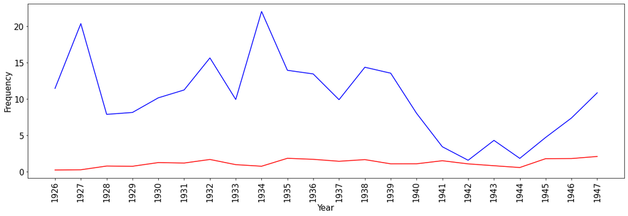

```python
"""
SCRIPT #9

For each script, the normalised data will be provided directly as a variable both for transparency and so that the user is not strictly required to run any scripts except for S4 and S7.

As a reminder:
test1 = ["radioactivity","radiation","nuclear","atomic","isotope"]
"""
rads = ({'year_bias1926.txt': 11.45412894076579, 'year_bias1927.txt': 20.360051435919416, 'year_bias1928.txt': 7.890065093037017, 'year_bias1929.txt': 8.151131568853089, 'year_bias1930.txt': 10.15959022986073, 'year_bias1931.txt': 11.239638458296259, 'year_bias1932.txt': 15.643739896751317, 'year_bias1933.txt': 9.929967596947842, 'year_bias1934.txt': 22.022389429253074, 'year_bias1935.txt': 13.943112102621305, 'year_bias1936.txt': 13.441555084526703, 'year_bias1937.txt': 9.905280752801337, 'year_bias1938.txt': 14.361331090230191, 'year_bias1939.txt': 13.546056592414208, 'year_bias1940.txt': 8.045052292839904, 'year_bias1941.txt': 3.439676670392983, 'year_bias1942.txt': 1.5825288811520812, 'year_bias1943.txt': 4.313753684664606, 'year_bias1944.txt': 1.844224503596238, 'year_bias1945.txt': 4.716703024585814, 'year_bias1946.txt': 7.385524372230429, 'year_bias1947.txt': 10.851135978297728}, {'1926.txt': 0.2445475674364372, '1927.txt': 0.2749110662700616, '1928.txt': 0.7909331487338902, '1929.txt': 0.7569966528873485, '1930.txt': 1.2666016523960573, '1931.txt': 1.2022685563933049, '1932.txt': 1.6917673997906066, '1933.txt': 0.980521653726752, '1934.txt': 0.7622066058496697, '1935.txt': 1.8535736011681458, '1936.txt': 1.7139329436215902, '1937.txt': 1.4426689375344388, '1938.txt': 1.6714910793927018, '1939.txt': 1.0947877675713438, '1940.txt': 1.0987896409493543, '1941.txt': 1.517691108164678, '1942.txt': 1.088006233757621, '1943.txt': 0.8317165930086778, '1944.txt': 0.5863320665007169, '1945.txt': 1.801452518998471, '1946.txt': 1.8193356392690603, '1947.txt': 2.1037773894340637})

t_data(rads)
```

The output of S9 is surprising, particularly with regards to the *Nature* dataset. The frequency of nuclear-related terminology appears to sharply decline between 1939 and 1947, when it returns to its regular rates. This dip in frequency follows a sequence of peaks, the largest being in 1934. Checking the corresponding plaintext file reveals that there indeed happens to be an abundance of nuclear-related terminology, and skimming through the collected abstracts that contain those terms reveals experimentation with unstable isotopes of various atoms, some indeed being uranium. If there is one fault in the test variable, it is that it did not initially include 'uranium'.

Looking further into the drop and corroborating with some outside information, the span between 1939 and 1947 overlaps the active period of the Manhattan Project— which ran from 1942 to 1946— completely. Investigating the dip reveals that there indeed was a period of censorship beginning in 1939, in which the number of American publications related to nuclear physics declined. This makes sense, considering the United States has consistently been a top three scientific publisher since 1900, [6] thus a decline American research to any subject reflects sharply in the data. In 1943, the Office of Censorship sent a notice to every newspaper and radio station in the United States, ordering them to refrain from publishing information about nuclear science. [7] This does not completely explain the small hump in 1943, though it does explain the continued absence of research until 1947.

[6]: https://direct.mit.edu/qss/article/3/1/37/109076/Scopus-1900-2020-Growth-in-articles-abstracts Refer to Figs. 7 and 8 especially when regarding American dominance in scientific publishing. Also note the sharp decline in both figs. for all nations' output corresponding with the 1940s.

[7]: https://archive.org/details/secretsofvictory00swee/page/200/mode/2up Borrow the book using a free account and refer to page 200.

```
The red line represents archive.org data.
```

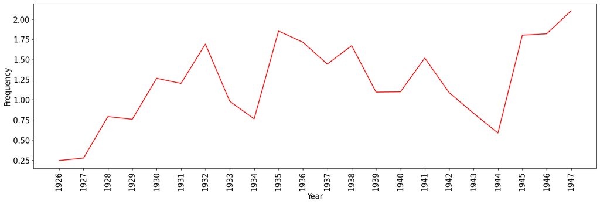

```python
"""
SCRIPT #10

This is the Amazing Stories data for the test variable 'rads' representing nuclear-related terminology. It has been isolated to reveal relationships which were not plainly visible in S9.

test1 = ["radioactivity","radiation","nuclear","atomic","isotope"]
"""
rads = ({'year_bias1926.txt': 11.45412894076579, 'year_bias1927.txt': 20.360051435919416, 'year_bias1928.txt': 7.890065093037017, 'year_bias1929.txt': 8.151131568853089, 'year_bias1930.txt': 10.15959022986073, 'year_bias1931.txt': 11.239638458296259, 'year_bias1932.txt': 15.643739896751317, 'year_bias1933.txt': 9.929967596947842, 'year_bias1934.txt': 22.022389429253074, 'year_bias1935.txt': 13.943112102621305, 'year_bias1936.txt': 13.441555084526703, 'year_bias1937.txt': 9.905280752801337, 'year_bias1938.txt': 14.361331090230191, 'year_bias1939.txt': 13.546056592414208, 'year_bias1940.txt': 8.045052292839904, 'year_bias1941.txt': 3.439676670392983, 'year_bias1942.txt': 1.5825288811520812, 'year_bias1943.txt': 4.313753684664606, 'year_bias1944.txt': 1.844224503596238, 'year_bias1945.txt': 4.716703024585814, 'year_bias1946.txt': 7.385524372230429, 'year_bias1947.txt': 10.851135978297728}, {'1926.txt': 0.2445475674364372, '1927.txt': 0.2749110662700616, '1928.txt': 0.7909331487338902, '1929.txt': 0.7569966528873485, '1930.txt': 1.2666016523960573, '1931.txt': 1.2022685563933049, '1932.txt': 1.6917673997906066, '1933.txt': 0.980521653726752, '1934.txt': 0.7622066058496697, '1935.txt': 1.8535736011681458, '1936.txt': 1.7139329436215902, '1937.txt': 1.4426689375344388, '1938.txt': 1.6714910793927018, '1939.txt': 1.0947877675713438, '1940.txt': 1.0987896409493543, '1941.txt': 1.517691108164678, '1942.txt': 1.088006233757621, '1943.txt': 0.8317165930086778, '1944.txt': 0.5863320665007169, '1945.txt': 1.801452518998471, '1946.txt': 1.8193356392690603, '1947.txt': 2.1037773894340637})

as_data(rads)
```

```
The blue line represents nature.com data, the red line represents archive.org data.
```

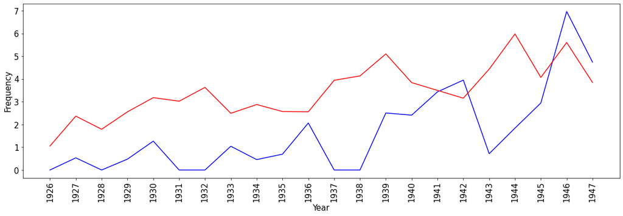

```python
"""
SCRIPT #11

test2 = ["war","warfare","battle","wars"]
"""
war = ({'year_bias1926.txt': 0.0, 'year_bias1927.txt': 0.5357908272610373, 'year_bias1928.txt': 0.0, 'year_bias1929.txt': 0.47947832757959336, 'year_bias1930.txt': 1.2699487787325912, 'year_bias1931.txt': 0.0, 'year_bias1932.txt': 0.0, 'year_bias1933.txt': 1.0452597470471412, 'year_bias1934.txt': 0.4587997797761057, 'year_bias1935.txt': 0.6971556051310653, 'year_bias1936.txt': 2.0679315514656467, 'year_bias1937.txt': 0.0, 'year_bias1938.txt': 0.0, 'year_bias1939.txt': 2.508528998595224, 'year_bias1940.txt': 2.4135156878519712, 'year_bias1941.txt': 3.439676670392983, 'year_bias1942.txt': 3.956322202880202, 'year_bias1943.txt': 0.7189589474441009, 'year_bias1944.txt': 1.844224503596238, 'year_bias1945.txt': 2.947939390366134, 'year_bias1946.txt': 6.975217462662071, 'year_bias1947.txt': 4.747371990505256}, {'1926.txt': 1.0564454913254087, '1927.txt': 2.3711079465792815, '1928.txt': 1.7922980526355126, '1929.txt': 2.560429855354267, '1930.txt': 3.1838074322523844, '1931.txt': 3.02640015919694, '1932.txt': 3.63581590305876, '1933.txt': 2.495873300395369, '1934.txt': 2.8804319407109613, '1935.txt': 2.5733122867281173, '1936.txt': 2.562579352599271, '1937.txt': 3.9473025096428396, '1938.txt': 4.139674168589402, '1939.txt': 5.1090095819996035, '1940.txt': 3.8457637433227396, '1941.txt': 3.502364095764641, '1942.txt': 3.160399059962614, '1943.txt': 4.438740133214734, '1944.txt': 5.987694133658836, '1945.txt': 4.072849173387847, '1946.txt': 5.609618221079603, '1947.txt': 3.851324102701976})

t_data(war)
```

The output of S11 pertains to words relating to war. There is very little of interest except for the upward trend in mentions.

```
The blue line represents nature.com data, the red line represents archive.org data.
```

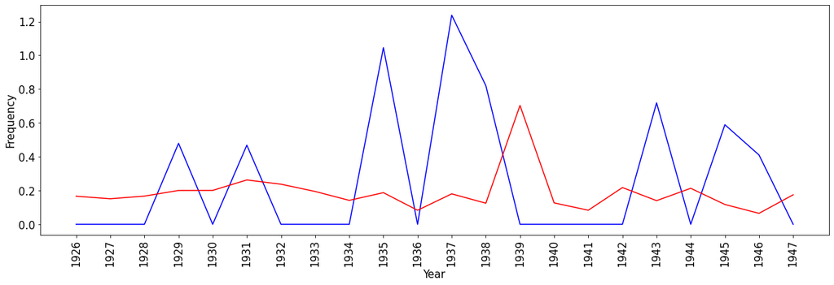

```python
"""
SCRIPT #12

test3 = ["freeze","freezing","cryogenic","cryogenics","microwave"]
"""
hamsters = ({'year_bias1926.txt': 0.0, 'year_bias1927.txt': 0.0, 'year_bias1928.txt': 0.0, 'year_bias1929.txt': 0.47947832757959336, 'year_bias1930.txt': 0.0, 'year_bias1931.txt': 0.4683182690956774, 'year_bias1932.txt': 0.0, 'year_bias1933.txt': 0.0, 'year_bias1934.txt': 0.0, 'year_bias1935.txt': 1.0457334076965978, 'year_bias1936.txt': 0.0, 'year_bias1937.txt': 1.2381600941001671, 'year_bias1938.txt': 0.8206474908702966, 'year_bias1939.txt': 0.0, 'year_bias1940.txt': 0.0, 'year_bias1941.txt': 0.0, 'year_bias1942.txt': 0.0, 'year_bias1943.txt': 0.7189589474441009, 'year_bias1944.txt': 0.0, 'year_bias1945.txt': 0.5895878780732268, 'year_bias1946.txt': 0.41030690956835714, 'year_bias1947.txt': 0.0}, {'1926.txt': 0.1662923458567773, '1927.txt': 0.15120108644853392, '1928.txt': 0.1668941506502704, '1929.txt': 0.20038146694076872, '1930.txt': 0.20071829464199814, '1931.txt': 0.2625643973732505, '1932.txt': 0.2374410385671027, '1933.txt': 0.19448363379704173, '1934.txt': 0.1418058801580781, '1935.txt': 0.1873292469265679, '1936.txt': 0.08320062833114515, '1937.txt': 0.18033361719180485, '1938.txt': 0.12497129565552911, '1939.txt': 0.7037921362958638, '1940.txt': 0.12678342010954088, '1941.txt': 0.08338962132772955, '1942.txt': 0.21760124675152423, '1943.txt': 0.14007858408567206, '1944.txt': 0.21321166054571525, '1945.txt': 0.11748603384772635, '1946.txt': 0.06497627283103787, '1947.txt': 0.17475467132679123})

t_data(hamsters)
```

If the user compares the frequency labels of the output of S12 to other outputs, they will find they show much less significance. However, there is an extremely notable peak in the *Amazing Stories* data in in 1939. Investigating all previous peaks in the *Nature* data reveals no correlation, and every abstract containing the words "freeze" and "freezing" pertains to some branch of chemistry. However, looking into the *Amazing Stories* file corresponding with 1939 reveals a short shorty titled "World Beneath Ice." Searching for the title on the internet does not immediately yield the story itself, corroborating a point made in the introduction, that *Amazing Stories* represents not only popular writers, but common people writing stories for their own enjoyment or for others' validation. The influence of historical events on common people is seemingly reflected in narrative.

"World Beneath Ice" contains a notable quote regarding the freezing of cells:

> "If you knew much of science, you would realize that the quick-freezing of any animal or vegetable substance does not result in the cell-expansion and rupture that occurs in slow-freezing. Therefore, in an instantaneous freeze, there is no damage — just a complete suspension of activity. My daughter— all the peoples of Europe and Asia— are in a state, of suspended animatian, and if i were to allow the temperature to rise above freezing, slowly, carefully, almost all would revive . . ."

Its 1939 publication seemingly precedes research into cryopreservation, and is almost certainly inaccurate at the scales of entire human beings. An unfortunate drawback of the collected data is the notable lack of the term "microwave" anywhere, even though the application of microwave radiation to heat food was known since 1933. [4] This outcome demonstrates that the data-driven method is not foolproof, and there are considerable drawbacks to having little data.

It is worth mentioning that science fiction is often subject to authors with only superficial knowledge about a given subject, so certain concepts of science fiction stories may be conveyed at any level of accuracy, informed by the knowledge of the author, the popular knowledge of the subject, the tendency of public education to cover that subject, et cetera. Therefore it is advised to take great care with data-driven searches like this, since no script can discriminate a well-described concept from a poorly described concept.

The following cells exemplify one of the potential perils of data-driven methodology.

```
The blue line represents nature.com data, the red line represents archive.org data.
```

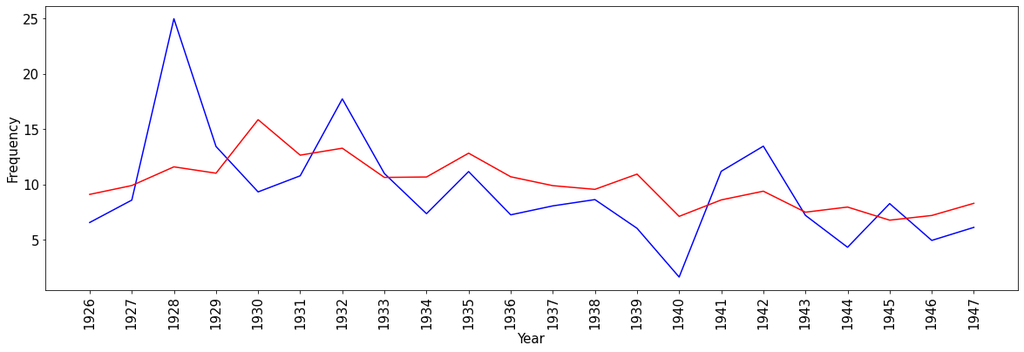

```python
"""
SCRIPT #13

test4 = ["light","travel","faster","speed"]
"""
ftl = ({'year_bias1926.txt': 6.545216537580451, 'year_bias1927.txt': 8.572653236176597, 'year_bias1928.txt': 24.98520612795056, 'year_bias1929.txt': 13.425393172228615, 'year_bias1930.txt': 9.312957710705668, 'year_bias1931.txt': 10.77132018920058, 'year_bias1932.txt': 17.729571882984825, 'year_bias1933.txt': 10.975227343994984, 'year_bias1934.txt': 7.340796476417691, 'year_bias1935.txt': 11.154489682097045, 'year_bias1936.txt': 7.237760430129763, 'year_bias1937.txt': 8.048040611651087, 'year_bias1938.txt': 8.616798654138115, 'year_bias1939.txt': 6.020469596628537, 'year_bias1940.txt': 1.6090104585679808, 'year_bias1941.txt': 11.178949178777195, 'year_bias1942.txt': 13.451495489792688, 'year_bias1943.txt': 7.18958947444101, 'year_bias1944.txt': 4.303190508391221, 'year_bias1945.txt': 8.254230293025175, 'year_bias1946.txt': 4.923682914820286, 'year_bias1947.txt': 6.103763987792472}, {'1926.txt': 9.087387605938005, '1927.txt': 9.889925609065466, '1928.txt': 11.581002801644852, '1929.txt': 11.006137610117039, '1930.txt': 15.849823956212958, '1931.txt': 12.63763902093882, '1932.txt': 13.267018029936864, '1933.txt': 10.623668496163406, '1934.txt': 10.662029614385498, '1935.txt': 12.817264263396753, '1936.txt': 10.682960677719038, '1937.txt': 9.878274808395533, '1938.txt': 9.544682705691036, '1939.txt': 10.92181130029507, '1940.txt': 7.099871526134288, '1941.txt': 8.589130996756143, '1942.txt': 9.377577538577592, '1943.txt': 7.476694425572746, '1944.txt': 7.942134355327893, '1945.txt': 6.755446946244265, '1946.txt': 7.179878147829684, '1947.txt': 8.280682887484877})

t_data(ftl)
```

The test variable 'ftl' has a fair intention: to search the dataset for suggestions of faster-than-light travel, an important aspect of science fiction. As such, the variable searches for terms like "light," "speed," and "travel." The output of S13 shows potential promise, displaying certain hallmarks of trends preceding trends. There are peaks in the years 1928 and 1932, somewhat reminiscent of the datapoints on nuclear-related terminology.

```python
"""
SCRIPT #14

An idea that immediately comes to mind following the test variable on faster-than-light travel is whether laser technology is mentioned throughout the datasets.
"""
lasers = gencomp(["laser","lazer","light"])
print(lasers)
```

```
The blue line represents nature.com data, the red line represents archive.org data.
```

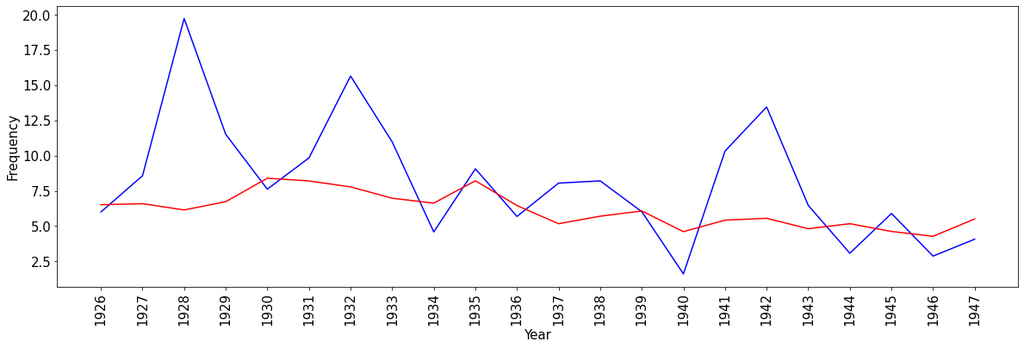

```python
"""
SCRIPT #15

The 'gencomp()' method yields the following datapoints, which appear relatively promising as well.
"""
lasers = ({'year_bias1926.txt': 5.999781826115414, 'year_bias1927.txt': 8.572653236176597, 'year_bias1928.txt': 19.725162732592544, 'year_bias1929.txt': 11.507479861910241, 'year_bias1930.txt': 7.619692672395546, 'year_bias1931.txt': 9.834683651009225, 'year_bias1932.txt': 15.643739896751317, 'year_bias1933.txt': 10.975227343994984, 'year_bias1934.txt': 4.587997797761057, 'year_bias1935.txt': 9.063022866703848, 'year_bias1936.txt': 5.686811766530528, 'year_bias1937.txt': 8.048040611651087, 'year_bias1938.txt': 8.206474908702967, 'year_bias1939.txt': 6.020469596628537, 'year_bias1940.txt': 1.6090104585679808, 'year_bias1941.txt': 10.319030011178949, 'year_bias1942.txt': 13.451495489792688, 'year_bias1943.txt': 6.470630526996909, 'year_bias1944.txt': 3.0737075059937298, 'year_bias1945.txt': 5.895878780732268, 'year_bias1946.txt': 2.8721483669784997, 'year_bias1947.txt': 4.0691759918616475}, {'1926.txt': 6.514747196506687, '1927.txt': 6.590992813824728, '1928.txt': 6.146058504381697, '1929.txt': 6.731332982047305, '1930.txt': 8.39556177243944, '1931.txt': 8.201682623211799, '1932.txt': 7.783614045527835, '1933.txt': 6.977100362468873, '1934.txt': 6.629424897390151, '1935.txt': 8.212908562622689, '1936.txt': 6.456368758496864, '1937.txt': 5.169563692831739, '1938.txt': 5.701815364283516, '1939.txt': 6.07346547247912, '1940.txt': 4.606464263979985, '1941.txt': 5.420325386302421, '1942.txt': 5.554012774229381, '1943.txt': 4.815201327944977, '1944.txt': 5.170382768233594, '1945.txt': 4.621117331343903, '1946.txt': 4.277604628043326, '1947.txt': 5.504772146793924})

t_data(lasers)
```

The output of S15 is visually similar to that of S13, which may suggest the term shared between them, "light," is having an effect on results. Investigating any of the peaks in the visualisation, reveals there are zero instances of the term "laser" or its misspelling anywhere in the plaintext files. This is simple to confirm:

```python
"""
SCRIPT #16
"""
terms = gencomp(["laser","lazer"])
print(terms)
```

```
({'year_bias1926.txt': 0.0, 'year_bias1927.txt': 0.0, 'year_bias1928.txt': 0.0, 'year_bias1929.txt': 0.0, 'year_bias1930.txt': 0.0, 'year_bias1931.txt': 0.0, 'year_bias1932.txt': 0.0, 'year_bias1933.txt': 0.0, 'year_bias1934.txt': 0.0, 'year_bias1935.txt': 0.0, 'year_bias1936.txt': 0.0, 'year_bias19…
```

```
The blue line represents nature.com data, the red line represents archive.org data.
```

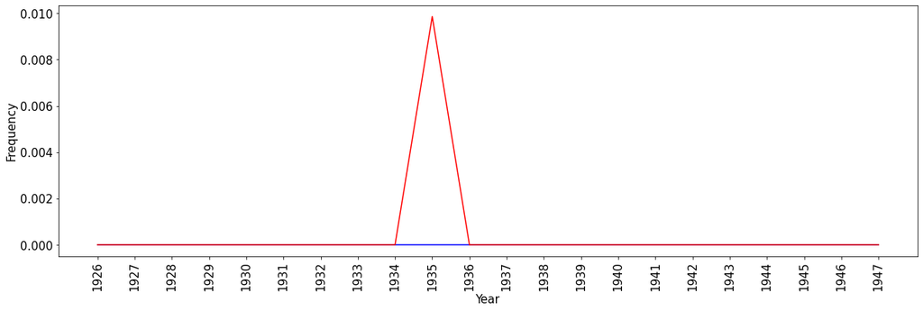

```python
"""
SCRIPT #17
"""
terms = ({'year_bias1926.txt': 0.0, 'year_bias1927.txt': 0.0, 'year_bias1928.txt': 0.0, 'year_bias1929.txt': 0.0, 'year_bias1930.txt': 0.0, 'year_bias1931.txt': 0.0, 'year_bias1932.txt': 0.0, 'year_bias1933.txt': 0.0, 'year_bias1934.txt': 0.0, 'year_bias1935.txt': 0.0, 'year_bias1936.txt': 0.0, 'year_bias1937.txt': 0.0, 'year_bias1938.txt': 0.0, 'year_bias1939.txt': 0.0, 'year_bias1940.txt': 0.0, 'year_bias1941.txt': 0.0, 'year_bias1942.txt': 0.0, 'year_bias1943.txt': 0.0, 'year_bias1944.txt': 0.0, 'year_bias1945.txt': 0.0, 'year_bias1946.txt': 0.0, 'year_bias1947.txt': 0.0}, {'1926.txt': 0.0, '1927.txt': 0.0, '1928.txt': 0.0, '1929.txt': 0.0, '1930.txt': 0.0, '1931.txt': 0.0, '1932.txt': 0.0, '1933.txt': 0.0, '1934.txt': 0.0, '1935.txt': 0.009859434048766732, '1936.txt': 0.0, '1937.txt': 0.0, '1938.txt': 0.0, '1939.txt': 0.0, '1940.txt': 0.0, '1941.txt': 0.0, '1942.txt': 0.0, '1943.txt': 0.0, '1944.txt': 0.0, '1945.txt': 0.0, '1946.txt': 0.0, '1947.txt': 0.0})

t_data(terms)
```

It is now obvious that the term "laser" and its misspelling had a negligible effect on results, and the output of S15 predominantly reflected the relative frequency of the term "light" throughout the datasets. The one peak in 1935 is the result of random chance, where an advertisement— which is usually garbled and excluded by the previous scripts— happened to contain a legible word. The following is the junk data:

> —or do they domlnsU ynuf Hits WiEn lYlMEariKI IV you that rsrs msseuHns magnetic force— rltsl **laser** PAV|/|PD

Mercifully, this kind of junk output did not occur more frequently. The method demonstrated in S2 made sure of that. However, this serves as a warning to inspect the datasets going into a project of similar methodology. As the saying goes: garbage in, garbage out.

```python
"""
SCRIPT #18
"""
light = gencomp(["light"])
print(light)
```

```
({'year_bias1926.txt': 5.999781826115414, 'year_bias1927.txt': 8.572653236176597, 'year_bias1928.txt': 19.725162732592544, 'year_bias1929.txt': 11.507479861910241, 'year_bias1930.txt': 7.619692672395546, 'year_bias1931.txt': 9.834683651009225, 'year_bias1932.txt': 15.643739896751317, 'year_bias1933.…
The blue line represents nature.com data, the red line represents archive.org data.
```

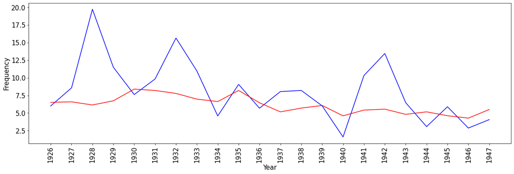

```python
"""
SCRIPT #19

The following script reveals the underlying pattern drawn by the term "light."
"""
light = ({'year_bias1926.txt': 5.999781826115414, 'year_bias1927.txt': 8.572653236176597, 'year_bias1928.txt': 19.725162732592544, 'year_bias1929.txt': 11.507479861910241, 'year_bias1930.txt': 7.619692672395546, 'year_bias1931.txt': 9.834683651009225, 'year_bias1932.txt': 15.643739896751317, 'year_bias1933.txt': 10.975227343994984, 'year_bias1934.txt': 4.587997797761057, 'year_bias1935.txt': 9.063022866703848, 'year_bias1936.txt': 5.686811766530528, 'year_bias1937.txt': 8.048040611651087, 'year_bias1938.txt': 8.206474908702967, 'year_bias1939.txt': 6.020469596628537, 'year_bias1940.txt': 1.6090104585679808, 'year_bias1941.txt': 10.319030011178949, 'year_bias1942.txt': 13.451495489792688, 'year_bias1943.txt': 6.470630526996909, 'year_bias1944.txt': 3.0737075059937298, 'year_bias1945.txt': 5.895878780732268, 'year_bias1946.txt': 2.8721483669784997, 'year_bias1947.txt': 4.0691759918616475}, {'1926.txt': 6.514747196506687, '1927.txt': 6.590992813824728, '1928.txt': 6.146058504381697, '1929.txt': 6.731332982047305, '1930.txt': 8.39556177243944, '1931.txt': 8.201682623211799, '1932.txt': 7.783614045527835, '1933.txt': 6.977100362468873, '1934.txt': 6.629424897390151, '1935.txt': 8.203049128573921, '1936.txt': 6.456368758496864, '1937.txt': 5.169563692831739, '1938.txt': 5.701815364283516, '1939.txt': 6.07346547247912, '1940.txt': 4.606464263979985, '1941.txt': 5.420325386302421, '1942.txt': 5.554012774229381, '1943.txt': 4.815201327944977, '1944.txt': 5.170382768233594, '1945.txt': 4.621117331343903, '1946.txt': 4.277604628043326, '1947.txt': 5.504772146793924})

t_data(light)
```

Yet again, the output appears promising. Investigating the large peaks in the *Nature* data reveals research done with regards to the velocity and the behaviour of light, probably spurred by quantum mechanics. However, certain issues in the terminology arise, since idioms like "new light" and "brought to light" as well as other definitions of the term, namely as the opposite of "heavy," skew the data. The issue is made much worse when investigating the *Amazing Science* data. While there are certainly intriguing datapoints, such as the publication of "The Colour out of Space" in 1927 by H. P. Lovecraft— whose entire premise hinges upon an impossible and corruptive colour of light— they pale in comparison to the commonplace and desirable usage of light to set the mood in a narrative.

Having technical and mathematical knowledge is only useful up to a certain point, since misconstruing certain commonalities as significances is much easier without an understanding of literature or narrative in general. Especially in an analysis of this kind, having an understanding of writing can better inform conclusions than the data alone. There are indeed cases in which the term "light" is used to refer to its speed in a vacuum, and occasionally in fascinating ways. One story, called "The Metal Horde," measures distance in light-seconds and incorporates the vastness of space in combination with the relatively slow speed of light to explain a failure in telecommunication. The majority, however, uses "light" to refer to brightness, and by extension as a way to control the description, be it following or limited by the light.

```
The blue line represents nature.com data, the red line represents archive.org data.
```

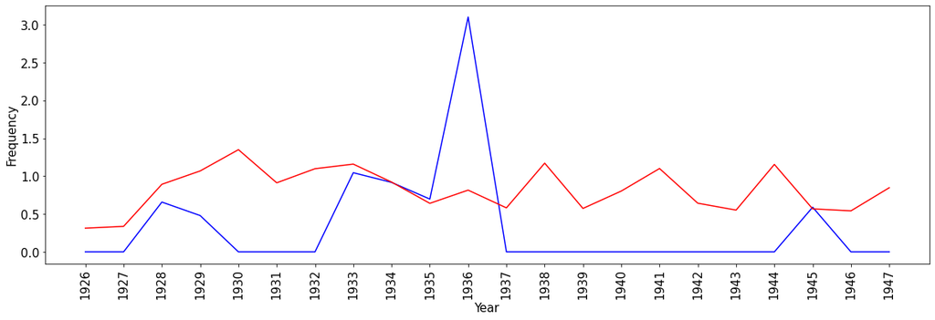

```python
"""
SCRIPT #20

test5 = ["gravity","warp","blackhole"]
"""
gravity = ({'year_bias1926.txt': 0.0, 'year_bias1927.txt': 0.0, 'year_bias1928.txt': 0.6575054244197516, 'year_bias1929.txt': 0.47947832757959336, 'year_bias1930.txt': 0.0, 'year_bias1931.txt': 0.0, 'year_bias1932.txt': 0.0, 'year_bias1933.txt': 1.0452597470471412, 'year_bias1934.txt': 0.9175995595522114, 'year_bias1935.txt': 0.6971556051310653, 'year_bias1936.txt': 3.10189732719847, 'year_bias1937.txt': 0.0, 'year_bias1938.txt': 0.0, 'year_bias1939.txt': 0.0, 'year_bias1940.txt': 0.0, 'year_bias1941.txt': 0.0, 'year_bias1942.txt': 0.0, 'year_bias1943.txt': 0.0, 'year_bias1944.txt': 0.0, 'year_bias1945.txt': 0.5895878780732268, 'year_bias1946.txt': 0.0, 'year_bias1947.txt': 0.0}, {'1926.txt': 0.3130208863186396, '1927.txt': 0.33676605618082556, '1928.txt': 0.8925208926079679, '1929.txt': 1.0687011570174332, '1930.txt': 1.349657498454815, '1931.txt': 0.9120658014018175, '1932.txt': 1.09816480337285, '1933.txt': 1.158798318040707, '1934.txt': 0.9217382210275077, '1935.txt': 0.6408632131698376, '1936.txt': 0.8153661576452226, '1937.txt': 0.581074988729149, '1938.txt': 1.1716058967705856, '1939.txt': 0.5734602592040372, '1940.txt': 0.802961660693759, '1941.txt': 1.1007430015260302, '1942.txt': 0.6424417761235477, '1943.txt': 0.5515594248373338, '1944.txt': 1.1548964946226243, '1945.txt': 0.567849163597344, '1946.txt': 0.5414689402586489, '1947.txt': 0.8468880225836806})


t_data(gravity)
```

The output of S20 demonstrates the first instance of reduplication skewing the data in some way. The steep peak in 1936 is induced by a reduplication of the word "gravity" to appear four times due to an abstract on an "ultracentrifuge" appearing twice. There are four notable peaks in the *Amazing Stories* data, and though they do not neecssarily correlate with any *Nature* data, since there is little mention of "gravity" in the first place, they still merit some investigation.

The 1930 peak is the result of "The Metal Horde," in which accelerations and planets alike are described in terms of Earth's gravity to impart a sense of scale. The peak in 1938 is the result of various assertions made about gravity by various writers, but more notably that of a spacefaring story in which "gravity detectors" take on the role of letting a spaceship crew know there is a celestial body nearby. It should be obvious this does not correlate with scientific understanding, not even that of the time, since Albert Einstein had already published about general and special relativity before then. [13](https://archive.org/details/principleofrelat00eins/page/n11/mode/2up) The peak in 1941 points to various stories about machines that manipulate gravity in some way, either by reversing it or nullifying it completely. And 1944 points to a genuinely baffling story whose premise is that gravity is not a *pulling* force, but a *pushing* force.

```
({'year_bias1926.txt': 0.0, 'year_bias1927.txt': 0.0, 'year_bias1928.txt': 0.0, 'year_bias1929.txt': 0.0, 'year_bias1930.txt': 0.0, 'year_bias1931.txt': 0.0, 'year_bias1932.txt': 0.0, 'year_bias1933.txt': 0.0, 'year_bias1934.txt': 0.0, 'year_bias1935.txt': 0.0, 'year_bias1936.txt': 0.0, 'year_bias19…
The blue line represents nature.com data, the red line represents archive.org data.
```

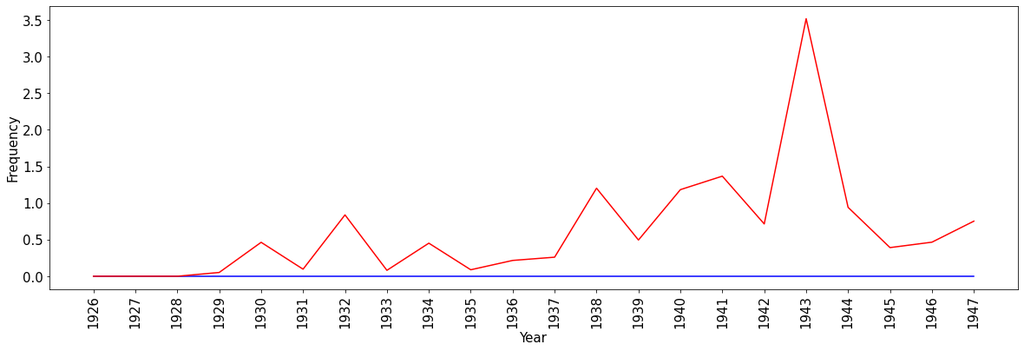

```python
"""
SCRIPT #21

A nearly ubiquitous concept in science fiction is that of the robot, which can take a myriad of forms. The idea to analyse the frequency of the term is obvious if not for the caveat robots were long considered no more than a novelty. Throughout the collected Nature dataset, there is absolutely no mention of robotics whatsoever. As a final demonstration, however, Amazing Stories exhibits a fascinating trend in the term's usage.
"""
robots = gencomp(["robot","robots"])

robots = ({'year_bias1926.txt': 0.0, 'year_bias1927.txt': 0.0, 'year_bias1928.txt': 0.0, 'year_bias1929.txt': 0.0, 'year_bias1930.txt': 0.0, 'year_bias1931.txt': 0.0, 'year_bias1932.txt': 0.0, 'year_bias1933.txt': 0.0, 'year_bias1934.txt': 0.0, 'year_bias1935.txt': 0.0, 'year_bias1936.txt': 0.0, 'year_bias1937.txt': 0.0, 'year_bias1938.txt': 0.0, 'year_bias1939.txt': 0.0, 'year_bias1940.txt': 0.0, 'year_bias1941.txt': 0.0, 'year_bias1942.txt': 0.0, 'year_bias1943.txt': 0.0, 'year_bias1944.txt': 0.0, 'year_bias1945.txt': 0.0, 'year_bias1946.txt': 0.0, 'year_bias1947.txt': 0.0}, {'1926.txt': 0.0, '1927.txt': 0.0, '1928.txt': 0.0, '1929.txt': 0.051950750688347445, '1930.txt': 0.4637284738280647, '1931.txt': 0.09673425166382914, '1932.txt': 0.8384636674400814, '1933.txt': 0.08103484741543406, '1934.txt': 0.45200624300387393, '1935.txt': 0.08873490643890058, '1936.txt': 0.21632163366097742, '1937.txt': 0.26048189149927364, '1938.txt': 1.2028487206844678, '1939.txt': 0.49526113294894114, '1940.txt': 1.1833119210223815, '1941.txt': 1.3675897897747646, '1942.txt': 0.7149755250407225, '1943.txt': 3.5194744251525107, '1944.txt': 0.941684834076909, '1945.txt': 0.3916201128257545, '1946.txt': 0.46566328862243805, '1947.txt': 0.7527893534077161})

t_data(robots)
```

[14]: Original Czech language version: https://archive.org/details/rurrossumsuniver00apekuoft/page/n1/mode/2up

[15]: Internet Speculative Fiction Database listing: https://www.isfdb.org/cgi-bin/title.cgi?17201

By now, both the pros and cons of this methodology should be clear. Data-driven analysis is a powerful tool for digital history, and it can reveal a lot about a given subject. Provided the user has a broad enough and a *deep* enough dataset, they can see the influence of historical events among common people. The ideal case was given first to make a good impression. The influence the Manhattan Project had on fiction and research alike was widespread and powerful, from censorship of scientific ideas to FBI investigations spurred by science fiction that precedes science fact.

It is unfortunate that the available free archives of *Astounding Stories* are highly limited, since access to them may allow for a new dimension of data. *Astounding Stories* in the popular conception was a much more consistent publisher with a higher rate of publication. That does not discount *Amazing Stories,* however, for harbouring some of the greatest and most prolific science fiction writers in history. Upon investigating the plaintext files gathered by S1, the user can spot authors like H. G. Wells, H. P. Lovecraft, Jules Vernes, and more.

The first editor of *Amazing Stories,* Hugo Gernsback, is recorded to have said:

> "Not only do these amazing tales make tremendously interesting reading— they are also always instructive. They supply knowledge that we might not otherwise obtain— and they supply it in a vert palatable form. For the best of these modern writers of scientifiction [sic] have the knack of imparting knowledge and even inspiration without once making us aware that we are being taught. [16]

Such a statement seems to have aged relatively well, considering the past analyses. The stories that he curated imparted knowledge well beyond their publication dates, likewise for *Nature.* Though not all the data was perfectly useful, and though not every concept could be mapped perfectly to some inspiration, the trends that did appear were certainly indicative of the time and place. As a methodology, this has potential.

[16]: *The History of Science Fiction,* Adam Roberts, p.176 (Science Library PN 3433.8 .R55 2006)

It is worth noting this data appears like a much rougher version of the Googe nGram viewer, which informed but a small part of the project at large. Performing similar searches to the ones performed in the preceding scripts may yield similar results, though backed by millions of books and near-infinite processing power. The technology already exists for large analysis. It need only be focused a little more tightly.

**Citations:**

1. [*Reflections: The Cleve Cartmill Affair, Part One* by Robert Silverberg](https://web.archive.org/web/20130618175748/http://www.asimovs.com/_issue_0310/ref.shtml): Evidence of the FBI investigation of the author of *Deadline.*
2. [*The Astounding Investigation: The Manhattan Project's Confrontation with Science Fiction* by Albert I. Berger](https://www.gwern.net/docs/1984-berger.pdf): Evidence for John Campbell's statement about scientific articles.
3. [*Short Wave Craft* November 1933 Issue](http://www.americanradiohistory.com/Archive-Short-Wave-Television/30s/SW-TV-1933-11.pdf): p.394 includes an article on cooking food with microwave radiation.
4. [*Short Wave Craft* March 1933 Issue](https://www.worldradiohistory.com/Archive-Short-Wave-Television/30s/SW-TV-1933-03.pdf): p.646 includes an article on potential medical applications of microwave heating.
5. [*Reanimation of rats from body temperatures between 0 and 1° C by microwave diathermy* by R. K. Andjus and J. E. Lovelock](https://physoc.onlinelibrary.wiley.com/doi/10.1113/jphysiol.1955.sp005323): A definite source of inspiration for much later science fiction stories regarding cryogenic space travel, preceding their sudden decline.
6. [*Scopus 1900–2020: Growth in articles, abstracts, countries, fields, and journals* by Mike Thelwall and Pardeep Sud](https://direct.mit.edu/qss/article/3/1/37/109076/Scopus-1900-2020-Growth-in-articles-abstracts): Meta-analysis that demonstrates consistent United States dominance in scientific publishing, which must then reflect in the *Nature* data.
7. [*Secrets of Victory: The Office of Censorship and the American Press and Radio in World War II* by Michael S. Sweeney](https://archive.org/details/secretsofvictory00swee/page/200/mode/2up): Citation demonstrating period of United States censorship of nuclear physics research between 1939 and 1947.
8. [*The actual content of quantum theoretical kinematics and mechanics* by Werner Heisenberg](https://ui.adsabs.harvard.edu/abs/1983ZhPhy..43..172H/abstract): English language version of Heisenberg's 1927 work on quantum mechanical principles.
9. [*Possible Existence of a Neutron* by James Chadwick](https://www.nature.com/articles/129312a0): An event to perhaps correspond with a peak in nuclear-related terminology in both *Amazing Science* and *Nature*.
10. [*This Month in Physics History: April 14, 1932: Cockcroft and Walton Split the Atom*](https://www.aps.org/publications/apsnews/201904/history.cfm): Potential source for popular conception of the atom in science fiction, and the catalyst for nuclear energy research manifesting later on in history.
11. [*Artificial Production of a New Kind of Radio-Element* by Irène Joliot-Curie and Frédéric Joliot](https://www.nature.com/articles/133201a0): Original paper describing artificially induced radioactivity, provided as a historical reference point and possible source of inspiration to *Amazing Stories* writers.
12. [*Radioactivity Induced by Neutron Bombardment* by Enrico Fermi](https://www.nature.com/articles/133757a0): English language version of Fermi's work on artificial radiation induction as a possible source for a peak in the *Nature* dataset with regards to nuclear-related terminology. Possible source of inspiration to *Amazing Stories* writers.
13. [*The Principle of Relativity* Original papers by Albert Einstein and Hermann Minkowski](https://archive.org/details/principleofrelat00eins/page/n11/mode/2up): This is an extremely early print publication of the theory of relativity, used to provide a reference point in history.
14. [*R.U.R.* by Karel Čapek](https://archive.org/details/rurrossumsuniver00apekuoft/page/n1/mode/2up): This is the original Czech language version of *Rossum's Universal Robots* published in 1920 as a reference point for the earliest mention of robots in fiction.
15. [*I, Robot* by Isaac Asimov](https://www.isfdb.org/cgi-bin/title.cgi?17201) This is an Internet Speculative Fiction Database listing for *I, Robot,* published in 1950. Since, for whatever reason, there are no high quality archives of the actual text that are actually available to borrow from archive.org, this is the best possible proof for its date of publication.
16. *The History of Science Fiction,* Adam Roberts (Science Library PN 3433.8 .R55 2006): Overall history source that proved not to be extremely significant for the narrow timeframe and holistic focus.